# Copia de EDAandModels

a work by:

Virginia Itzel Contreras Miranda

itzelvcm@gmail.com

This work presents an analysis of a real-life chemical detection platform that is exposed to a mixture of carbon monoxide (CO) and humid synthetic air in its gas chamber. The platform is composed of 14 temperature-modulated metal oxide semiconductor (MOX) gas sensors.

There are 13 datasets provided, each of them corresponds to a different measurement day. The datasets contain 20 variables:

1. Time (s): experiment time
2. CO concentration (ppm): its bottle contain1600 ppm of CO diluted in synthetic air with 21 ± 1% O2.
3. Humidity (%r.h.): it has a uniform distribution between 15% and 75% r.h. randomly chosen.
4. Temperature (ºC): its variation is below 3ºC.
5. Flow rate (mL/min): releases the gas mixtures at a 240 mln/min constant rate.
6. Heater voltage (V): controls the operating temperature of the sensors and is modulated in the range of .2-.9.
7. R1 (MOhm)
8. R2 (MOhm)
9. R3 (MOhm)
10. R4 (MOhm)
11. R5 (MOhm)
12. R6 (MOhm)
13. R7 (MOhm)
14. R8 (MOhm)
15. R9 (MOhm)
16. R10 (MOhm)
17. R11 (MOhm)
18. R12 (MOhm)
19. R13 (MOhm)
20. R14 (MOhm)

In this work, an exploratory data analysis of the dataset is going to be made as well the evaluation of several machine learning algorithms that will be able to predict the presence of CO (ppm) in the gas chamber.

It is necessary to import all the packages that you need to develop your work.

```python
from matplotlib.axes._axes import _log as matplotlib_axes_logger
import pandas as pd
import numpy as np
import os
import glob
from datetime import datetime
from sklearn.preprocessing import MinMaxScaler
import matplotlib.pyplot as plt
import seaborn as sns
import calmap
from sklearn.model_selection import train_test_split
from sklearn import preprocessing
from sklearn import utils
from sklearn import linear_model
from sklearn.metrics import accuracy_score
from sklearn.linear_model import LinearRegression
from sklearn.metrics import r2_score
from sklearn.model_selection import train_test_split
from numpy import mean
from numpy import std
from sklearn.model_selection import cross_val_score
from sklearn.feature_selection import SelectKBest
from sklearn.feature_selection import f_classif
from matplotlib import pyplot
from sklearn import metrics
from sklearn import model_selection
from scipy import stats
from sklearn.model_selection import cross_validate
import warnings
warnings.simplefilter(action='ignore', category=FutureWarning)
import probscale
import seaborn
from sklearn.tree import DecisionTreeRegressor
```

## Data cleaning

The first step of this analysis consists in import all the experiments made and concatenate them to have only one dataset instead of 13.

Every file contains the day and hour of when measurements started in their file names. It is necessary to assign the date of every individual dataset as an index or variable to have the possibility to make a different analysis as time series. In this case, the date is assigned in the index.

A for loop is implemented to assign the date for the 13 datasets and also to know if there are any missing or duplicated values in it. The analysis of the missing values is going to be individually by every dataset because if there is any, I would substitute those missing values by the mean of the column of such missing values on that specific date.

In this case, there are not any missing or duplicated values in any of the datasets, so now I'm able to concatenate them, finishing the data cleaning phase.

```python
path = "/Users/itzelcontreras/Desktop/dataset tempMod CO_RH/"
all_files = glob.glob(os.path.join(path, "*.csv")) #make list of paths

i=0
d={}
fec={}


for file in all_files:
    # Getting the file name without extension.
     fec[i] = os.path.splitext(os.path.basename(file))[0]

    # Reading the file content to create a DataFrame.
     d[i] = pd.read_csv(file)
     d[i].drop(d[i].iloc[:, 20:40], inplace = True, axis = 1)

    #Using the file name to know the date of the file.
     date_st= fec[i]
     format_st = '%Y%m%d_%H%M%S'
     dt = datetime.strptime(date_st, format_st)
     dat= dt.strftime('%Y-%m-%d')

    #Assign the date to the index of the file.
     d[i]['Date']=dat
     d[i]['Date'] = pd.to_datetime(d[i]['Date'])
     d[i].set_index('Date', inplace=True)

    #Check if there is any missing and duplicated values.
     dup= d[i].duplicated().sum()
     print("The dataset number %d has %d duplicated values and the following data corresponds to the number of missing values of every variable of the dataset:" % (i+1,dup))
     print(d[i].isna().sum())
     i+=1


    #concatenate all the files.
ds = pd.concat(d)
ds=ds.reset_index(level=0, drop=True)
```

```
The dataset number 1 has 0 duplicated values and the following data corresponds to the number of missing values of every variable of the dataset:
Time (s)              0
CO (ppm)              0
Humidity (%r.h.)      0
Temperature (C)       0
Flow rate (mL/min)    0
Heater voltage (V)    0
R1 (MOhm)             0
R2 (MOhm)             0
R3 (MOhm)             0
R4 (MOhm)             0
R5 (MOhm)             0
R6 (MOhm)             0
R7 (MOhm)             0
R8 (MOhm)             0
R9 (MOhm)             0
R10 (MOhm)            0
R11 (MOhm)            0
R12 (MOhm)            0
R13 (MOhm)            0
R14 (MOhm)            0
dtype: int64
The dataset number 2 has 0 duplicated values and the following data corresponds to the number of missing values of every variable of the dataset:
Time (s)              0
CO (ppm)              0
Humidity (%r.h.)      0
Temperature (C)       0
Flow rate (mL/min)    0
Heater voltage (V)    0
R1 (MOhm)             0
R2 (MOhm)             0
R3 (MOhm)             0
R4 (MOhm)             0
R5 (MOhm)             0
R6 (MOhm)             0
R7 (MOhm)             0
R8 (MOhm)             0
R9 (MOhm)             0
R10 (MOhm)            0
R11 (MOhm)            0
```

[output cut: 231 more lines]

```
R1 (MOhm)             0
R2 (MOhm)             0
R3 (MOhm)             0
R4 (MOhm)             0
R5 (MOhm)             0
R6 (MOhm)             0
R7 (MOhm)             0
R8 (MOhm)             0
R9 (MOhm)             0
R10 (MOhm)            0
R11 (MOhm)            0
R12 (MOhm)            0
R13 (MOhm)            0
R14 (MOhm)            0
dtype: int64
```

## Exploratory Data Analysis

The second step of the analysis is to make a data exploration of the variables because it helps us to understand better the dataset. This good understanding is necessary to know the behavior of the variables and the relationship between them. The data frame has a dimension of 3,843,147 x 20.

```python
print(ds.shape)
ds.head()
```

```
(3843147, 20)
```

| Date | Time (s) | CO (ppm) | Humidity (%r.h.) | Temperature (C) | Flow rate (mL/min) | Heater voltage (V) | R1 (MOhm) | R2 (MOhm) | R3 (MOhm) | R4 (MOhm) | R5 (MOhm) | R6 (MOhm) | R7 (MOhm) | R8 (MOhm) | R9 (MOhm) | R10 (MOhm) | R11 (MOhm) | R12 (MOhm) | R13 (MOhm) | R14 (MOhm) |
| --- | --- | --- | --- | --- | --- | --- | --- | --- | --- | --- | --- | --- | --- | --- | --- | --- | --- | --- | --- | --- |
| 2016-10-06 | 0.308 | 0.0 | 48.68 | 26.3 | 242.2372 | 0.2000 | 2.0493 | 1.4168 | 5.0799 | 26.3353 | 42.1858 | 34.4549 | 40.5595 | 52.3446 | 44.3207 | 57.7289 | 62.0947 | 50.3466 | 47.5846 | 64.8363 |
| 2016-10-06 | 0.616 | 0.0 | 48.68 | 26.3 | 241.7847 | 0.2000 | 1.8217 | 1.3087 | 4.4454 | 27.0332 | 43.0273 | 33.0403 | 39.4375 | 55.6363 | 43.1405 | 54.5033 | 60.7607 | 50.3466 | 45.7841 | 63.3641 |
| 2016-10-06 | 0.926 | 0.0 | 48.68 | 26.3 | 241.3294 | 0.1999 | 1.6296 | 1.2184 | 3.8753 | 25.3273 | 40.2166 | 30.9981 | 38.0325 | 55.9880 | 44.0625 | 55.1962 | 56.8068 | 49.2068 | 46.2782 | 65.2822 |
| 2016-10-06 | 1.234 | 0.0 | 48.68 | 26.3 | 240.8919 | 0.2000 | 1.4815 | 1.1406 | 3.4372 | 24.8041 | 39.8441 | 29.7207 | 37.3660 | 52.3446 | 42.4934 | 55.1962 | 60.7607 | 50.0306 | 46.2782 | 63.8761 |
| 2016-10-06 | 1.542 | 0.0 | 48.68 | 26.3 | 240.7936 | 0.1996 | 1.3486 | 1.0765 | 3.0548 | 20.6505 | 39.3142 | 28.0483 | 36.4079 | 53.0355 | 42.4934 | 52.8143 | 60.7607 | 49.4614 | 46.5522 | 64.3090 |

It is important to know the basic statistics of every variable.

```python
ds.describe()
```

|  | Time (s) | CO (ppm) | Humidity (%r.h.) | Temperature (C) | Flow rate (mL/min) | Heater voltage (V) | R1 (MOhm) | R2 (MOhm) | R3 (MOhm) | R4 (MOhm) | R5 (MOhm) | R6 (MOhm) | R7 (MOhm) | R8 (MOhm) | R9 (MOhm) | R10 (MOhm) | R11 (MOhm) | R12 (MOhm) | R13 (MOhm) | R14 (MOhm) |
| --- | --- | --- | --- | --- | --- | --- | --- | --- | --- | --- | --- | --- | --- | --- | --- | --- | --- | --- | --- | --- |
| count | 3.843147e+06 | 3.843147e+06 | 3.843147e+06 | 3.843147e+06 | 3.843147e+06 | 3.843147e+06 | 3.843147e+06 | 3.843147e+06 | 3.843147e+06 | 3.843147e+06 | 3.843147e+06 | 3.843147e+06 | 3.843147e+06 | 3.843147e+06 | 3.843147e+06 | 3.843147e+06 | 3.843147e+06 | 3.843147e+06 | 3.843147e+06 | 3.843147e+06 |
| mean | 4.545218e+04 | 9.900512e+00 | 4.600408e+01 | 2.571731e+01 | 2.399454e+02 | 3.551076e-01 | 1.641473e+01 | 1.847119e+01 | 2.303731e+01 | 2.144498e+01 | 3.262187e+01 | 2.956494e+01 | 3.281935e+01 | 2.799318e+01 | 2.368596e+01 | 2.616841e+01 | 2.833566e+01 | 2.629419e+01 | 2.328359e+01 | 2.919879e+01 |
| std | 2.624233e+04 | 6.427518e+00 | 1.246779e+01 | 9.402136e-01 | 1.855238e+00 | 2.885425e-01 | 2.391405e+01 | 2.762031e+01 | 2.920823e+01 | 1.777051e+01 | 2.784818e+01 | 2.774817e+01 | 2.822065e+01 | 2.058476e+01 | 1.876281e+01 | 2.093527e+01 | 2.115837e+01 | 1.937177e+01 | 1.806999e+01 | 2.261724e+01 |
| min | 3.070000e-01 | 0.000000e+00 | 1.634000e+01 | 1.379980e+01 | 0.000000e+00 | 1.980000e-01 | 3.150000e-02 | 5.480000e-02 | 5.100000e-02 | 2.970000e-02 | 4.490000e-02 | 4.640000e-02 | 4.940000e-02 | 3.100000e-02 | 2.890000e-02 | 3.600000e-02 | 3.050000e-02 | 3.270000e-02 | 3.210000e-02 | 3.130000e-02 |
| 25% | 2.272744e+04 | 4.440000e+00 | 3.657000e+01 | 2.518000e+01 | 2.398965e+02 | 2.000000e-01 | 4.109000e-01 | 4.882000e-01 | 5.888000e-01 | 1.990900e+00 | 1.802400e+00 | 1.545600e+00 | 1.890500e+00 | 1.191450e+01 | 7.988600e+00 | 7.802200e+00 | 1.067840e+01 | 9.817900e+00 | 7.825300e+00 | 9.804800e+00 |
| 50% | 4.545297e+04 | 8.890000e+00 | 4.709000e+01 | 2.602000e+01 | 2.399721e+02 | 2.000000e-01 | 1.974300e+00 | 1.516000e+00 | 4.621600e+00 | 2.171560e+01 | 3.427920e+01 | 2.434890e+01 | 3.338920e+01 | 2.784050e+01 | 2.199390e+01 | 2.399740e+01 | 2.782300e+01 | 2.640040e+01 | 2.204970e+01 | 2.740270e+01 |
| 75% | 6.817698e+04 | 1.556000e+01 | 5.576000e+01 | 2.638000e+01 | 2.400442e+02 | 2.070000e-01 | 2.886010e+01 | 3.262990e+01 | 4.683610e+01 | 3.459230e+01 | 5.338240e+01 | 5.083690e+01 | 5.402310e+01 | 4.236790e+01 | 3.627780e+01 | 4.081740e+01 | 4.321890e+01 | 4.046330e+01 | 3.595290e+01 | 4.550490e+01 |
| max | 9.091013e+04 | 2.000000e+01 | 8.381000e+01 | 2.742000e+01 | 3.212093e+02 | 9.026000e-01 | 1.280195e+02 | 1.998105e+02 | 2.229919e+02 | 1.120863e+02 | 2.132301e+02 | 1.914518e+02 | 2.287794e+02 | 1.247718e+02 | 1.151069e+02 | 1.485568e+02 | 1.259891e+02 | 1.299261e+02 | 9.820950e+01 | 1.294220e+02 |

It can be difficult to give an interpretation of the quantiles just with the numerical values, for that reason it is indispensable to graph a box plot for every variable of the dataset to see graphically the data distribution.

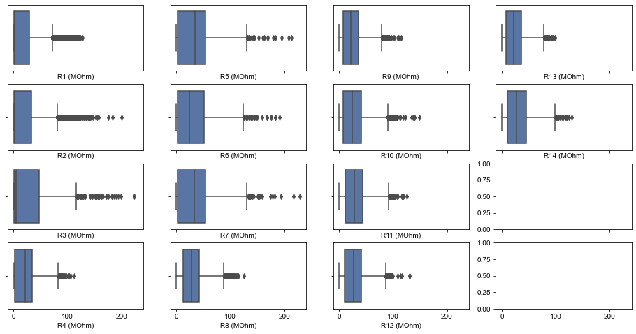

```python
#Plot the 14 gas sensors.
fig, axes = plt.subplots(4, 4, sharex=True, figsize=(16,8))
sns.set_theme(style="whitegrid")
x= 1
f = 0
i= 6 #In this location of the dataset the first sensor starts.

#To graph more efficiently, a for loop is used.
for f in range(3):
    for x in range(4):
        ax= sns.boxplot(ax=axes[x,f],x= ds.iloc[:,i])
        x+=1
        i+=1
    f+=1
x=0

#The last two graph boxes are not useful, so this for loop assign the last two sensors in the last column.
for x in range(2):
    ax= sns.boxplot(ax=axes[x,3],x= ds.iloc[:,i])
    x+=1
    i+=1
```

The resistance from R8 to 14 look very alike with an apparently normal distribution. In comparison with the resistance from R1 to R7 that corresponds from another distributor, the first three resistences show positive skewness, and the other four resistances have a normal distribution.

The variable time, CO, humidity, temperature, flow rate, and heater Voltage are graphed apart, because the range of every variable is quite different, so it was needed to graph every boxplot with its own y-axis.

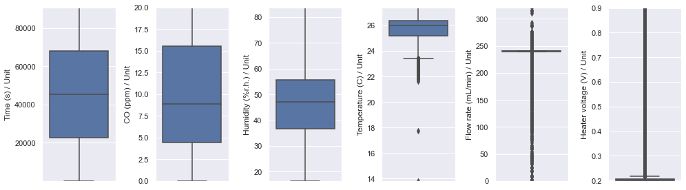

```python
sns.set(rc={'figure.figsize':(14,4)})
df=ds.iloc[:,0:6]
selection = ['Time (s)','CO (ppm)', 'Humidity (%r.h.)','Temperature (C)','Flow rate (mL/min)','Heater voltage (V)']
fig, axes = plt.subplots(1, len(selection))

#This for loop is is used to graph a variable in every iteration.
for j, col in enumerate(selection):
    ax = sns.boxplot(y=df[col], ax=axes.flatten()[j])
    ax.set_ylim(df[col].min(), df[col].max())
    ax.set_ylabel(col + ' / Unit')
fig.tight_layout()
```

The time, CO, and humidity have approximately equal proportions in all the quantiles. The temperature has some outliers and its distribution has negative skewness. The flow rate variable has as it's mean the constant released specify in the experimental protocol. The heater voltage variable maintains the limits recommended by the manufacturer.

A mean and standard deviation plot of the CO variable are going to be graphed to see how much the mean and standard deviation are changing over time.

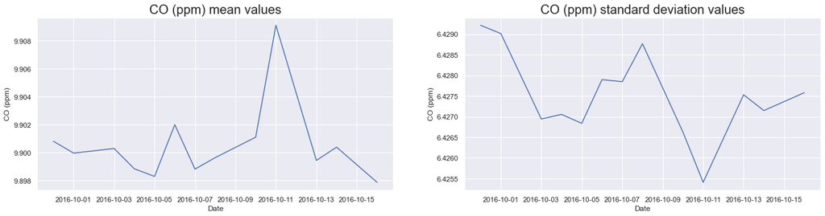

```python
#Size of the figures.
sns.set(rc={'figure.figsize':(22,5)})
f, axes = plt.subplots(1, 2)

#Mean plot.
sns.lineplot(x=ds.groupby(ds.index).mean().index,
             y=ds.groupby(ds.index).mean()['CO (ppm)'] , ax=axes[0] )
axes[0].set_title('CO (ppm) mean values',fontsize=20)

#Standard deviation plot.
sns.lineplot(x=ds.groupby(ds.index).mean().index,
             y=ds.groupby(ds.index).std()['CO (ppm)'] , ax=axes[1])
axes[1].set_title('CO (ppm) standard deviation values',fontsize=20)

plt.show()
```

A lag plot is presented. This graph allows us to check for the randomness and seasonality of our CO variable.

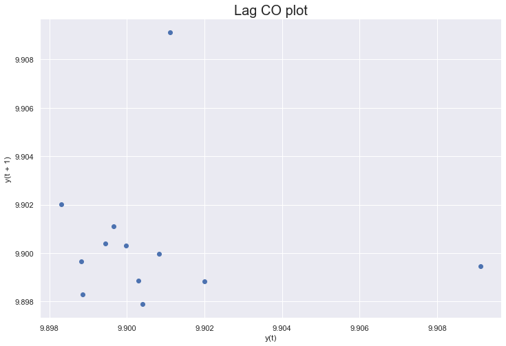

```python
matplotlib_axes_logger.setLevel('ERROR')

plt.figure(figsize=(12,8))

pd.plotting.lag_plot(ds.groupby(ds.index).mean()['CO (ppm)'], lag = 1)
plt.title("Lag CO plot", size=20)
plt.show()
```

The lag plot demonstrates that the variable CO hasn't any seasonality. I consider that the data is not randomness because almost all the data has a pattern, is concentrated almost in the same place in the graph.

A probability plot is made to visually compare the CO values with a normal distribution. It can be seen that it is really well distributed.

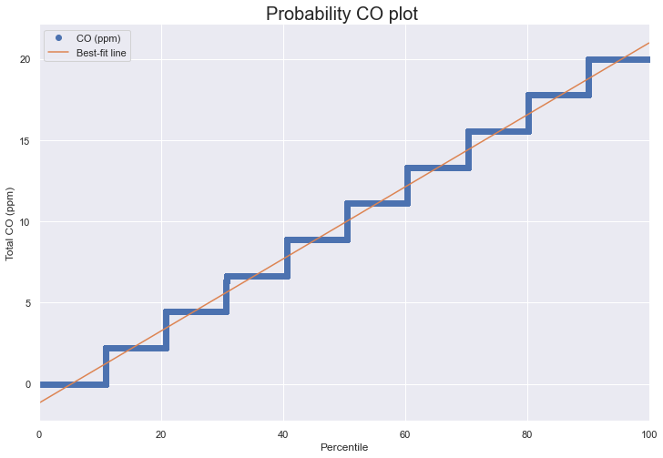

```python
fig, ax = pyplot.subplots(figsize=(12, 8))
fig = probscale.probplot(ds['CO (ppm)'], ax=ax, plottype='pp', bestfit=True,
                         problabel='Percentile', datalabel='Total CO (ppm)',
                         scatter_kws=dict(label='CO (ppm)'),
                         line_kws=dict(label='Best-fit line'))
ax.legend(loc='upper left')
plt.title("Probability CO plot ", size=20)
seaborn.despine()
```

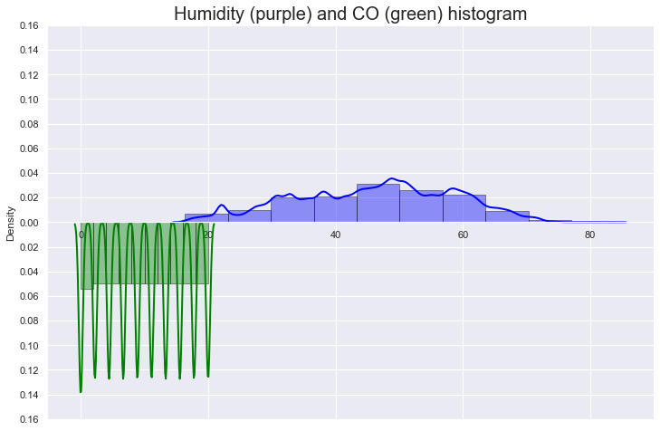

```python
green = ds['CO (ppm)']
purple = ds['Humidity (%r.h.)']

fig, ax = pyplot.subplots(figsize=(12, 8))

#Graph the CO variable.
sns.distplot(green, hist=True, kde=True, hist_kws={'edgecolor': 'black'}, kde_kws={'linewidth': 2}, bins=10,
             color='green', label="ji")
# Put the histogram upside down.
for p in ax.patches:
    p.set_height(-p.get_height())

#Put the line upside down.
for l in ax.lines:
    l.set_ydata(-l.get_ydata())

#Graph the humidity variable.
sns.distplot(purple, hist=True, kde=True, hist_kws={'edgecolor': 'black'}, kde_kws={'linewidth': 2}, bins=10,
             color='blue')
ax.spines['top'].set_visible(False)
ax.spines['right'].set_visible(False)


pos_ticks = np.array([t for t in ax.get_yticks() if t > 0])
ticks = np.concatenate([-pos_ticks[::-1], [0], pos_ticks])
ax.set_yticks(ticks)
ax.set_yticklabels([f'{abs(t):.2f}' for t in ticks])
ax.spines['bottom'].set_position('zero')

plt.title("Humidity (purple) and CO (green) histogram",size=20)
ax.set(xlabel=None)
plt.show()
```

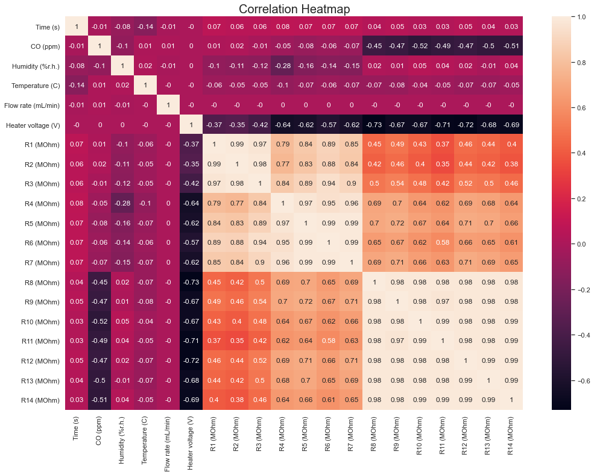

```python
plt.figure(figsize=(17,12))
sns.heatmap(np.round(ds.corr(),2),annot=True)
plt.title("Correlation Heatmap",size=20)
plt.show()
```

This heat map shows the correlation between all the variables of the dataset. It is notorious the high correlation between the gas sensors from the same distributor.

An interesting observation of this graph is a high negative correlation between the CO and the gas sensors from R8 to R14 that corresponds to one specific distributor (FIS SB-500-12 units). The CO variable has a small correlation with the other seven gas sensors.

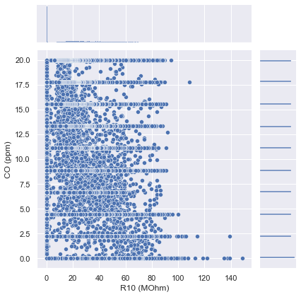

```python
sns.set(rc={'figure.figsize':(12,6)})
sns.jointplot(x='R10 (MOhm)', y= 'CO (ppm)', data= ds )
plt.show()
```

A visualization is presented with a scatterplot of the CO and the R10 resistance, which is the gas sensor with more correlation to the dependent variable. When an instance has a high CO value, the R10 is low (in most cases).

### Modelling

Before implementing the models that are going to be used, it is necessary to take into consideration some modifications of our data to be able to make a better analysis of our dataset.

```python
#Just put the CO variable at the end of the data frame.
col = list(ds.columns.values)
col.pop(col.index('CO (ppm)'))
ds = ds[col+['CO (ppm)']]
```

```python
ds.head()
```

| Date | Time (s) | Humidity (%r.h.) | Temperature (C) | Flow rate (mL/min) | Heater voltage (V) | R1 (MOhm) | R2 (MOhm) | R3 (MOhm) | R4 (MOhm) | R5 (MOhm) | R6 (MOhm) | R7 (MOhm) | R8 (MOhm) | R9 (MOhm) | R10 (MOhm) | R11 (MOhm) | R12 (MOhm) | R13 (MOhm) | R14 (MOhm) | CO (ppm) |
| --- | --- | --- | --- | --- | --- | --- | --- | --- | --- | --- | --- | --- | --- | --- | --- | --- | --- | --- | --- | --- |
| 2016-10-06 | 0.308 | 48.68 | 26.3 | 242.2372 | 0.2000 | 2.0493 | 1.4168 | 5.0799 | 26.3353 | 42.1858 | 34.4549 | 40.5595 | 52.3446 | 44.3207 | 57.7289 | 62.0947 | 50.3466 | 47.5846 | 64.8363 | 0.0 |
| 2016-10-06 | 0.616 | 48.68 | 26.3 | 241.7847 | 0.2000 | 1.8217 | 1.3087 | 4.4454 | 27.0332 | 43.0273 | 33.0403 | 39.4375 | 55.6363 | 43.1405 | 54.5033 | 60.7607 | 50.3466 | 45.7841 | 63.3641 | 0.0 |
| 2016-10-06 | 0.926 | 48.68 | 26.3 | 241.3294 | 0.1999 | 1.6296 | 1.2184 | 3.8753 | 25.3273 | 40.2166 | 30.9981 | 38.0325 | 55.9880 | 44.0625 | 55.1962 | 56.8068 | 49.2068 | 46.2782 | 65.2822 | 0.0 |
| 2016-10-06 | 1.234 | 48.68 | 26.3 | 240.8919 | 0.2000 | 1.4815 | 1.1406 | 3.4372 | 24.8041 | 39.8441 | 29.7207 | 37.3660 | 52.3446 | 42.4934 | 55.1962 | 60.7607 | 50.0306 | 46.2782 | 63.8761 | 0.0 |
| 2016-10-06 | 1.542 | 48.68 | 26.3 | 240.7936 | 0.1996 | 1.3486 | 1.0765 | 3.0548 | 20.6505 | 39.3142 | 28.0483 | 36.4079 | 53.0355 | 42.4934 | 52.8143 | 60.7607 | 49.4614 | 46.5522 | 64.3090 | 0.0 |

The scales of several variables of the dataset have a different range of values. For that reason, it is essential to normalize the data, in this case, the MinMaxScaler method it is applied. MinMaxScaler subtracts the minimum value in the feature and then divides by the range. The default range for the feature returned a value between 0 and 1. The MinMax Scaler is not going to be applied in the CO variable because your dependent variable does not necessarily need to be normally distributed.

```python
scaler = MinMaxScaler()
ds_scaled = pd.DataFrame(scaler.fit_transform(ds), index=ds.index, columns=ds.columns)
ds_scaled['CO (ppm)'] = ds['CO (ppm)']
```

I Assign all the variables except CO as the independent variable.

```python
X = ds_scaled.iloc[:,0:19].values
```

I Assign CO variable as the dependent variable.

```python
y = ds_scaled['CO (ppm)'].values
```

Our dataset contains 20 variables. Sometimes when are too many attributes, it is no the best idea to include all of them in our machine learning model because some features can be irrelevant for the dependent variable. Feature selection helps in selecting the most appropriate variables of the dataset. The ANOVA F-value feature selection is used in this study. This feature selection method examines if, when we group the numerical feature by the dependent variable, the means for each group are significantly different.

```
Feature 0: 93.826387
Feature 1: 108.864517
Feature 2: 4.787092
Feature 3: 27.526671
Feature 4: 1.480729
Feature 5: 4.145906
Feature 6: 4.542701
Feature 7: 5.044992
Feature 8: 12.286960
Feature 9: 13.409275
Feature 10: 10.266811
Feature 11: 11.771618
Feature 12: 283.760938
Feature 13: 319.589036
Feature 14: 409.154866
Feature 15: 351.803400
Feature 16: 302.600989
Feature 17: 370.384535
Feature 18: 391.826700
```

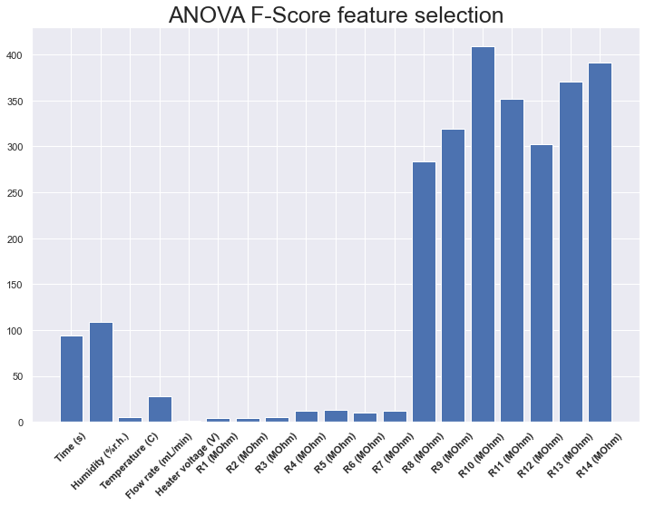

```python
#Divide the independent and dependent variable in a train and test set.
X_trainset, X_testset, y_trainset, y_testset = train_test_split(X, y, test_size=0.3, random_state=3)


plt.figure(figsize=(12,8))
def select_features(X_trainset, y_trainset, X_testset):

# Configure to select all features.
    fs = SelectKBest(score_func=f_classif, k=2)

# Learn relationship from training data.
    fs.fit(X_trainset, y_trainset)
# Transform train input data.
    X_trainset_fs = fs.transform(X_trainset)

# Transform test input data.
    X_testset_fs = fs.transform(X_testset)
    return X_trainset_fs, X_testset_fs, fs

X_trainset_fs, X_testset_fs, fs = select_features(X_trainset, y_trainset, X_testset)

# This for loop is in charge to obtain the scores of the features.
for i in range(len(fs.scores_)):
    print('Feature %d: %f' % (i, fs.scores_[i]))

# Plot the scores
pg=pyplot.bar([i for i in range(len(fs.scores_))], fs.scores_)

#Assign the names of the variables in the graphic.
my_xticks = ['Time (s)', 'Humidity (%r.h.)', 'Temperature (C)', 'Flow rate (mL/min)',
       'Heater voltage (V)', 'R1 (MOhm)', 'R2 (MOhm)', 'R3 (MOhm)',
       'R4 (MOhm)', 'R5 (MOhm)', 'R6 (MOhm)', 'R7 (MOhm)', 'R8 (MOhm)',
       'R9 (MOhm)', 'R10 (MOhm)', 'R11 (MOhm)', 'R12 (MOhm)', 'R13 (MOhm)',
       'R14 (MOhm)']

x=np.array([0,1,2,3,4,5,6,7,8,9,10,11,12,13,14,15,16,17,18])

y=fs.scores_
plt.xticks(x,my_xticks,rotation=45,fontweight ="bold")
plt.title("ANOVA F-Score feature selection",size=25)
plt.show()
```

The attributes with higher scores are from the R8 to the R14 resistance. Other relevant attributes are the time, humidity, and flow rate. It makes a lot of sense that the resistances (R8-R14) affect significantly the dependent variable because in the EDA section we demonstrate the high negative correlation between the CO and these 7 resistances.

These attributes are recommendations of the feature selection, so with this criteria, I am going to propose three variations of the dataset to analyze with every model:

1. Dataset 1 = The original dataset with all the features
2. Dataset 2 = 7 features of the original dataset (R8, R9, R10, R11, R12, R13, R14).
3. Dataset 3 = 10 features of the original dataset (Time, humidity, flow rate, R8, R9, R10, R11, R12, R13, R14).

Three models are going to be used in this analysis:

1. Linear regression: models the relationship between two variables by fitting a linear equation to observed data.
2. Decision Tree: has a tree structure that breaks down a dataset into smaller subsets.
3. Lasso regression: is a type of linear regression algorithm that penalizing the absolute size of the regression coefficients.

We need to split the dataset into train and test set, but instead of making just one split of the whole dataset, k-folds cross-validation is applied. The dataset is divided into k-folds, in this case, there will be 10. There will be 10 datasets and in ten iterations, all the datasets are going to be the train set nine times and the test set one time. As an example, in the first iteration, dataset #1 is going to be a test set, and the rest of the datasets are going to be the train. In the second iteration, dataset #2 is going to be the test set and the rest of the datasets, the train.

Three metrics are going to be evaluated:

1. R-squared: represents how close the data are to the fitted regression line.
2. Mean Squared Error (MSE): represents the average of the squared difference between the original and predicted values in the dataset. It measures the variance of the residuals.
3. Mean absolute error (MAE): represents the average of the absolute difference between the actual and predicted values in the dataset.

The bigger the value of R-squared and the lower the value of MSE and MAE it is better.

Every model implemented is going to obtain 10 results per metric for the k-folds cross-validation implementation. I will obtain the mean of those ten results for every metric in all the models.

```python
Xft = ds_scaled.iloc[:,12:19].values
xf= ds_scaled.drop(ds_scaled.iloc[:, 4:12],axis = 1)
Xf2= xf.drop(['Temperature (C)'],axis = 1)
Xft2=Xf2.iloc[:,:-1].values

#X:dataset 1, Xft:dataset 2, Xft2: dataset 3.
FS=[X,Xft,Xft2]
y = ds_scaled['CO (ppm)'].values


names = []
models = []

#Models to be used.
models.append(('Linear Regression', LinearRegression()))
models.append(('Decision Tree' ,DecisionTreeRegressor(random_state=0)))
models.append(('Lasso Regression',linear_model.Lasso(alpha=0.1)))

#Metrics to be obtained.
scoring = ['r2','neg_mean_squared_error','neg_mean_absolute_error']


t=[]


#This for loop is in charge to select one of the three datasets.
for k in range(3):
    X = FS[k]

#This for loop is in charge to apply all the models that are in the models array.
    for name, model in models:

        scores = model_selection.cross_validate(model, X, y, scoring=scoring, cv= 10)
        sorted(scores.keys())
        ['fit_time', 'score_time', 'test_r2', 'test_neg_mean_squared_error',
        'test_neg_mean_absolute_error']

        #Mean value of the three metrics in an array.
        zx= [np.mean(scores['test_r2']),abs(np.mean(scores['test_neg_mean_squared_error'])),
        abs(np.mean(scores['test_neg_mean_absolute_error']))]

        #The array of every model is append in the t array.
        t.append(zx)
        print("The %s algorithm using the dataset number %d obtain the following results for R-squared,MSE and MAE respectively: " % (name,k+1))
        print(zx)
```

```
The Linear Regression algorithm using the dataset number 1 obtain the following results for R-squared,MSE and MAE respectively:
[0.5735168837708455, 17.602013828087753, 3.0203493846963396]
The Decision Tree algorithm using the dataset number 1 obtain the following results for R-squared,MSE and MAE respectively:
[0.9126935855693002, 3.653481439394375, 0.5116849314578251]
The Lasso Regression algorithm using the dataset number 1 obtain the following results for R-squared,MSE and MAE respectively:
[0.48934817733528996, 21.07783605746342, 3.548411460329961]
The Linear Regression algorithm using the dataset number 2 obtain the following results for R-squared,MSE and MAE respectively:
[0.4661476541978334, 22.03101713930754, 3.5926406139232356]
The Decision Tree algorithm using the dataset number 2 obtain the following results for R-squared,MSE and MAE respectively:
[0.7582365920515601, 10.025908792419761, 1.4505110068632034]
The Lasso Regression algorithm using the dataset number 2 obtain the following results for R-squared,MSE and MAE respectively:
[0.2534191388190815, 30.800845853611783, 4.565543001950928]
The Linear Regression algorithm using the dataset number 3 obtain the following results for R-squared,MSE and MAE respectively:
[0.4720481725929381, 21.787756838514937, 3.576738884565527]
The Decision Tree algorithm using the dataset number 3 obtain the following results for R-squared,MSE and MAE respectively:
[0.9378939585675458, 2.600927916928921, 0.3408182292652888]
The Lasso Regression algorithm using the dataset number 3 obtain the following results for R-squared,MSE and MAE respectively:
[0.25356474105368554, 30.794912807079715, 4.565331056066112]
```

The combination of the three algorithms with the three datasets gives, as a result, nine metric results. These results can be appreciated in a better way in a graph.

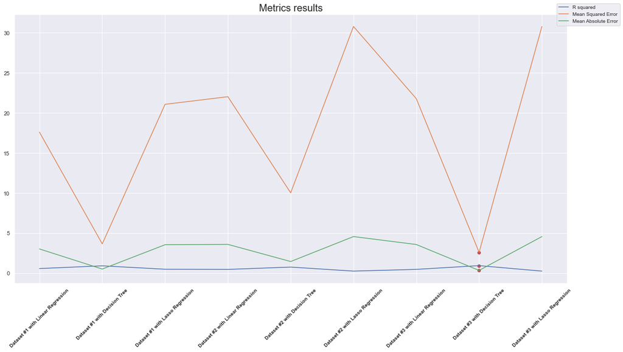

```python
# Transpose the array that has the 9 arrays of results.
j=np.array(t)
tr=j.transpose()
tr

# Know the highest value obtain by r-squared(M1), MSE(M2), and MAE(MAE).
M1 = max(tr[0])
M2 = min(tr[1])
M3 = min(tr[2])


L1=np.argmax(tr[0])
L2=np.argmin(tr[1])
L3=np.argmin(tr[2])



# Put the highest values of the metrics in an array to graph a dot to make more evidient which is the better.
dots_to_add = [M1,M2,M3]
x =np.array([1,2,3,4,5,6,7,8,9])
op=0
kl=2
Models = ['R squared','Mean Squared Error','Mean Absolute Error']
plt.figure(figsize=(20,10))


# This for loop makes the graph of the three arrays ( an array per metric).
for op in range(3):

    y = np.array(tr[op])
    plt.plot(x, y, label = Models[op])
    plt.legend(bbox_to_anchor=(1.1, 1.05),prop={'size': 10})


my_xticks = ['Dataset #1 with Linear Regression',
        'Dataset #1 with Decision Tree',
          'Dataset #1 with Lasso Regression',
          'Dataset #2 with Linear Regression',
          'Dataset #2 with Decision Tree',
          'Dataset #2 with Lasso Regression',
          'Dataset #3 with Linear Regression',
          'Dataset #3 with Decision Tree',
          'Dataset #3 with Lasso Regression']

#This for loop graphs the dots with the highest value of every metric.
for dot in dots_to_add:
    plt.scatter(8, dot, color='r')


plt.xticks(x, my_xticks,rotation=45,size=10,fontweight ="bold")
plt.title("Metrics results", size=20)
plt.show()
```

In this graph the three metrics of all models are displayed to be able to compare each of them. The best results are obtained by the decision tree algorithm. The linear and lasso regression algorithms performed poorly. The decision tree with the original dataset (#1) and dataset # 3 have slightly similar results.

Besides obtaining good results with the decision tree implementation, also a noticeable dimensionality reduction can be done by analyzing just 10 features, which represents 47.5 % less data than the original. This is such a good accomplishment because is possible to invest less time running models for having fewer features to analyze and therefore, you can apply more complex and slower machine learning algorithms such as support vector machine and multilayer perceptron.